# Homework 5

Charlotte Fowler

11/8/2019

# Problem 1

```r
#loading packages
library(tidyverse)
```

```r
#reading in data
set.seed(10)

iris_with_missing = iris %>%
  map_df(~replace(.x, sample(1:150, 20), NA)) %>%
  mutate(Species = as.character(Species))
```

```r
#writing function to fill in missing values
missing_values_fix = function(x){
  if (is.numeric(x)) {
    ifelse(is.na(x), mean(x, na.rm = TRUE), x)
  } else if (is.character(x)) {
    ifelse(is.na(x), "virginica", x)
  }


}

#performing function on iris data
output = map(iris_with_missing, missing_values_fix)


#creating new data
iris_data = tibble(
  sepal_length = output[[1]],
  sepal_width = output[[2]],
  petal_length = output[[3]],
  petal_width = output[[4]],
  species = output[[5]]
)
```

# Problem 2

```r
#reading in and tidying the data
file_names = list.files("data")

combined_df = map_dfr(.x = file_names, ~ read_csv(str_c("data/",.x)))

combined_df = combined_df %>%
  mutate(
    id = file_names
  ) %>%
  separate(id, into = c("group", "id"), sep = "_") %>%
  mutate(id = str_remove(id, ".csv")) %>%
  pivot_longer(week_1:week_8, names_to = "week", values_to = "value") %>%
  mutate(week = str_remove(week, "week_"))
```

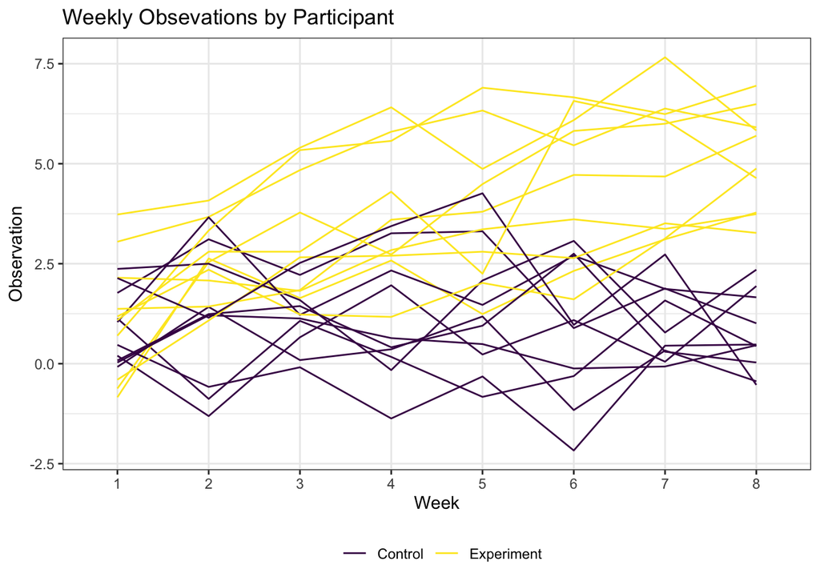

```r
#making spaghetti plot
combined_df %>%
  mutate(unique_id = paste(id, group, sep = "_")) %>%
  ggplot(aes(y = value, x = week, group = unique_id, color = group)) +
  geom_line() +
  viridis::scale_color_viridis(
    discrete = TRUE,
    name = "",
    breaks=c("con", "exp"),
    labels=c("Control", "Experiment")
    ) +
  theme_bw() +
  labs(title = "Weekly Obsevations by Participant", y = "Observation", x = "Week") +
  theme(legend.position = "bottom")
```

It appears that the control group tended to have lower values than the experiment group, especially as time progressed.

# Problem 3

```r
#writing function to run regression
sim_regression = function(beta1, n = 30, beta0 = 2) {

  sim_data = tibble(
    x = rnorm(n),
    y = beta0 + beta1 * x + rnorm(n, 0, sqrt(50))
  )

  ls_fit = broom::tidy(lm(y ~ x, data = sim_data))

  tibble(
    beta1_hat = pull(ls_fit, estimate)[2],
    beta1_hat_pvalue = pull(ls_fit, p.value)[2]
  )
}
```

```r
#running simulation 10000 for beta1 = 0
output = vector("list", 10000)

for (i in 1:10000) {
  output[[i]] = sim_regression(0)
}

results_b1_0 = bind_rows(output)
```

```r
#running sim for beta1 ={0,1,2,3,4,5,6}
sim_results =
  tibble(beta1 = 0:6) %>%
  mutate(
    output_lists = map(.x = beta1, ~rerun(10000, sim_regression(beta1 = .x))),
    estimate_dfs = map(output_lists, bind_rows)) %>%
  select(-output_lists) %>%
  unnest(estimate_dfs)
```

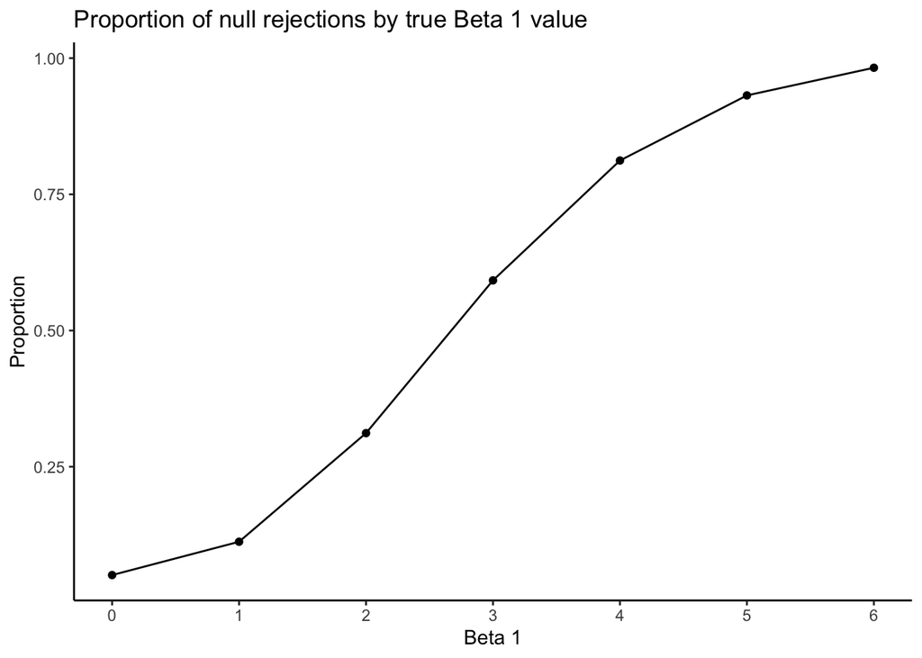

```r
#plotting proportion of rejections by beta1
sim_results %>%
  group_by(beta1) %>%
  filter(beta1_hat_pvalue<0.05) %>%
  count() %>%
  mutate(prop = n/10000) %>%
  ggplot(aes(y = prop, x = beta1)) +
  geom_line() +
  geom_point() +
  labs(title = "Proportion of null rejections by true Beta 1 value", y = "Proportion") +
  theme_classic() +
  scale_x_continuous(name="Beta 1", breaks=0:6)
```

As effect size ($\beta_1$) increases, the probability we reject the null approaches 1, and therefore the power increases significantly. By the time $\beta_1 = 6$ given the experiment conditions, we are almost certain to reject the null.

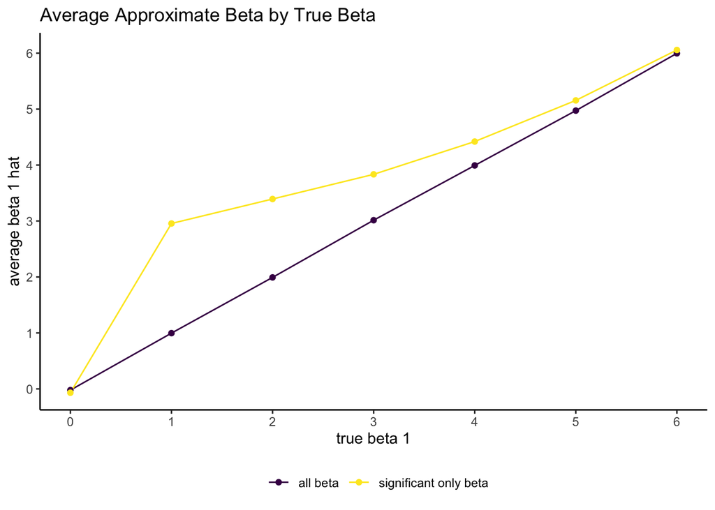

```r
#calculating avg beta hat
all_beta_avgs = sim_results %>%
  group_by(beta1) %>%
  summarise(all_beta1 = mean(beta1_hat))

#calculating avg sig beta hat
sig_beta_avgs = sim_results %>%
  filter(beta1_hat_pvalue<0.05) %>%
  group_by(beta1) %>%
  summarise(sig_beta1 = mean(beta1_hat))

#creating graph of average betas
left_join(all_beta_avgs, sig_beta_avgs, by = "beta1") %>%
  pivot_longer(cols = c(all_beta1, sig_beta1), names_to = "type", values_to = "avg") %>%
  ggplot(aes(x = beta1, y = avg, color = type)) +
  geom_line() +
  geom_point() +
  labs(title = "Average Approximate Beta by True Beta") +
  viridis::scale_color_viridis(
    discrete = TRUE,
    name = "",
    breaks=c("all_beta1", "sig_beta1"),
    labels=c("all beta", "significant only beta")) +
  theme_classic() +
  scale_x_continuous(name="true beta 1", breaks=0:6) +
  scale_y_continuous(name="average beta 1 hat", breaks=0:6) +
  theme(legend.position = "bottom")
```

The average $\hat{\beta_1}$ tends to be larger among $\hat{\beta_1}$ which rejected the mean. This is especially true among $\beta_1 = 1,2,3$. For these $\beta_1$’s, the null will only be rejected if $\hat{\beta_1}$ is much larger than 0, and therefore larger than $\beta_1$. For larger values of $\beta_1$ the null is almost always rejected, as this criteria will already be fufilled. Therefore, as $\beta_1$ increases, the average of all $\hat{\beta_1}$s approaches that of the $\hat{\beta_1}$ which rejected the mean. At $\beta_1 = 0$, we are equally likely to reject because of very large or very small values, and this results in the two averages being essentially equal.